# Tax Avoidance and Endogeneous Selection Bias

# 2 Simulation

Assume the following: 1. We have to types of tax strategies ($T$): normal (0) and agressive (1) 1. $T=1$ (agressive tax strategy) leads to lower mean tax rates but also higher tax rate volatility 1. Mean and volatility are further influenced by specific business characteristics that also affect firm value.

For simplicity, I model this as

We can compare this to a regression regressing *MtB* on *T* directly:

Note, the total impact of *T* in this scenario is actually quite small (-0.005). Let’s set up a simluation with a strong confounder and quite a bit of noise:

```r
set.seed(999)
nr_samples <- 10000
N <- 1000
compute_regression <- function(N) {
  u1_i <- rnorm(n=N, mean=0, sd=0.1)
  u2_i <- rnorm(n=N, mean=0, sd=0.1)
  e <- rnorm(n=N, mean=0, sd=1)
  m_i <- rnorm(n=N, mean=2, sd=2)
  v_i <- rnorm(n=N, mean=3, sd=3)
  T <- rbinom(n=N, size=1, prob=0.5)
  mean_tax <- 0.35 - 0.15 * T + m_i + u1_i
  vola_tax <- 0.1 + 0.1 * T + v_i + u2_i
  MtB <- 2 - 0.1 * mean_tax - 0.2 * vola_tax + m_i - v_i + e
  fit1 <- lm(MtB ~ mean_tax + vola_tax)
  fit2 <- lm(MtB ~ T)
  return(c(coef(fit1), coef(fit2)))
}
coefficients <- t(replicate(nr_samples, compute_regression(N=N)))
```

These are the results of the simulation

```r
summary(coefficients)
```

```
  (Intercept)       mean_tax         vola_tax       (Intercept)             T
 Min.   :1.652   Min.   :0.8286   Min.   :-1.240   Min.   :-0.48384   Min.   :-1.030072
 1st Qu.:1.839   1st Qu.:0.8848   1st Qu.:-1.206   1st Qu.: 0.01847   1st Qu.:-0.183435
 Median :1.880   Median :0.8955   Median :-1.198   Median : 0.14615   Median :-0.004146
 Mean   :1.879   Mean   :0.8955   Mean   :-1.198   Mean   : 0.14604   Mean   :-0.004296
 3rd Qu.:1.919   3rd Qu.:0.9061   3rd Qu.:-1.191   3rd Qu.: 0.27341   3rd Qu.: 0.174110
 Max.   :2.162   Max.   :0.9593   Max.   :-1.157   Max.   : 0.93431   Max.   : 0.899941
```

As you can see, estimating the effect of *T* via *T* alone works. Estimating, mean_tax and vola_tax coefficients separately, however, does not work. The reason is the presence of the *intermediate confounder* $m$ and $v$. They do not interfere with T, because they are not directly connected to T. But once we bring mean_tax and vola_tax into the picture, they become and issue. Now, the big question is whether our sharpe ratio is any better. After all, The inputs to our ratio are also tainted by $m$ and $v$. So, is *TPS* a good measure of T? It can only be so, if it correctly corresponds to the relative aggressiveness in tax strategies. In the toy simlation above, we only had two strategies 1 (agressive) or 0 (normal) Ideally our TPS measure will classifiy firms correctly into agressive and normal, even in the prence of $m$ and $v$.

Let’s make this clearer by again simulating things

```r
set.seed(999)
N <- 1000
u1_i <- rnorm(n=N, mean=0, sd=0.1)
u2_i <- rnorm(n=N, mean=0, sd=0.1)
m_i <- rnorm(n=N, mean=2, sd=2)
v_i <- rnorm(n=N, mean=3, sd=3)
TS <- rbinom(n=N, size=1, prob=0.5)
mean_tax <- 0.35 - 0.15 * T + m_i + u1_i
vola_tax <- 0.1 + 0.1 * T + v_i + u2_i
TPS <- (1-mean_tax) / vola_tax
tps_comparison <- cbind(TS=TS, TPS=TPS)
by(data=tps_comparison, INDICES=TS, summary)
```

```
INDICES: 0
       TS         TPS
 Min.   :0   Min.   :-37.6151
 1st Qu.:0   1st Qu.: -0.6821
 Median :0   Median : -0.2148
 Mean   :0   Mean   :  0.1792
 3rd Qu.:0   3rd Qu.:  0.2011
 Max.   :0   Max.   :185.1158
-----------------------------------------------------------------------------------------------------------------------
INDICES: 1
       TS         TPS
 Min.   :1   Min.   :-122.4965
 1st Qu.:1   1st Qu.:  -0.7314
 Median :1   Median :  -0.2031
 Mean   :1   Mean   :   0.4070
 3rd Qu.:1   3rd Qu.:   0.1962
 Max.   :1   Max.   : 492.2366
```

```r
mean_tps_agg <- (1- (0.35-0.15))/(0.1+0.1)
mean_tps_nom <- (1- (0.35))/(0.1)
cat(paste(mean_tps_nom, "vs", mean_tps_agg, "\n"))
```

```
6.5 vs 4
```

```r
mean_tps_agg <- (1- (0.35-0.15+2))/(0.1+0.1+3)
mean_tps_nom <- (1- (0.35+2))/(0.1+3)
cat(paste(mean_tps_nom, "vs", mean_tps_agg))
```

```
-0.435483870967742 vs -0.375
```

$$TPS = \frac{1-(0.35-0.15T+m+u_1)}{0.1+0.1T+v+u_2}$$

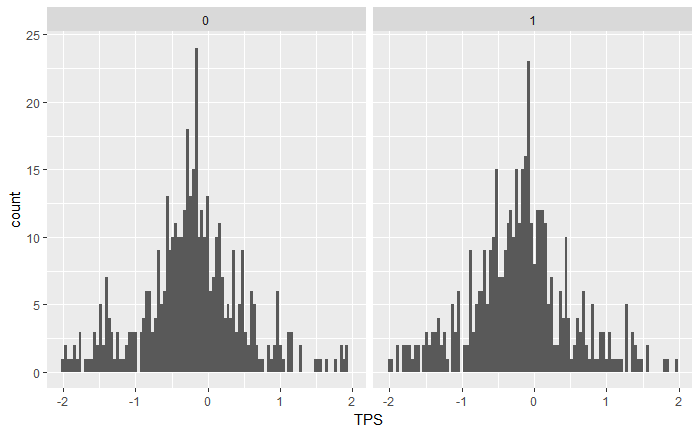

```r
graph_data <- as_tibble(tps_comparison)
graph_data <- graph_data[TPS < 2 & TPS > -2, ]
ggplot(data=graph_data) +
  geom_histogram(aes(x=TPS), bins=100) +
  facet_wrap(~TS)
```

Hmm, that doesn’t seem to be the way forward. One can see that the massive amount of interference from $m$ and $v$ makes this really hard to judge. It’s probably more complicated than that. Also, we always say that managemen chooses where to position itself on the risk return portfolio for many reasons like firm characteristics, management ability, corp gov, etc. A simple 1/0 agressive/not agressive cut, might be godd for the simulation, but not helpful anymore here?… Think about that.

What we might work is when v=m??

$$TPS = \frac{1-(0.35-0.15T+m+u_1)}{0.1+0.1T+m+u_2}$$

```r
set.seed(999)
N <- 1000
u1_i <- rnorm(n=N, mean=0, sd=0.1)
u2_i <- rnorm(n=N, mean=0, sd=0.1)
m_i <- rnorm(n=N, mean=2, sd=2)
v_i <- rnorm(n=N, mean=3, sd=3)
TS <- rbinom(n=N, size=1, prob=0.5)
mean_tax <- 0.35 - 0.15 * T + m_i + u1_i
vola_tax <- 0.1 + 0.1 * T + m_i + u2_i
TPS <- (1-mean_tax) / vola_tax
tps_comparison2 <- cbind(TS=TS, TPS=TPS)
by(data=tps_comparison2, INDICES=TS, summary)
```

```
INDICES: 0
       TS         TPS
 Min.   :0   Min.   :-970.6464
 1st Qu.:0   1st Qu.:  -0.7903
 Median :0   Median :  -0.6388
 Mean   :0   Mean   :  -2.4838
 3rd Qu.:0   3rd Qu.:  -0.3936
 Max.   :0   Max.   :  96.9690
-----------------------------------------------------------------------------------------------------------------------
INDICES: 1
       TS         TPS
 Min.   :1   Min.   :-103.0390
 1st Qu.:1   1st Qu.:  -0.7829
 Median :1   Median :  -0.6290
 Mean   :1   Mean   :  -0.1800
 3rd Qu.:1   3rd Qu.:  -0.3147
 Max.   :1   Max.   : 173.5618
```

$$\frac{\triangle TPS}{\triangle m} = \frac{-(0.1+0.1T+m+u_2)-(1-(0.35-0.15T+m+u_1))}{(0.1+0.1T+m+u_2)^2}$$

$$\frac{\triangle TPS}{\triangle m} = \frac{-0.1-0.1T-m-u_2- 1+0.35-0.15T+m+u_1}{(0.1+0.1T+m+u_2)^2}$$

$$\frac{\triangle TPS}{\triangle m} = \frac{-0.75-0.25T-u_2+u_1}{(0.1+0.1T+m+u_2)^2}$$

Ignoring the $u$s, tps would be negatively related to $m$… Can we get rid of this somehow? by reexpressing the tps??? Or can we say the magenitude is much smaller? If so under which scenarios? Can we mabe get rid of the problem by using decile ranks or something? (probably not)

# 3 References

Elwert, Felix. 2013. “Graphical Causal Models.” In *Handbook of Causal Analysis for Social Research*, 245–73. Springer.

Elwert, Felix, and Christopher Winship. 2014. “Endogenous Selection Bias: The Problem of Conditioning on a Collider Variable.” *Annual Review of Sociology* 40: 31–53.

Pearl, Judea. 2009. *Causality*. Cambridge University Press.